# process_idt_sweep

```python
# Always run this block first whenever you change the bvd_library.py file, otherwise the change won't be updated to this notebook.
import importlib
import bvd_library
importlib.reload(bvd_library)
from bvd_library import *

# add %matplotlib widget to make plots interactive
%matplotlib widget
mpl.style.use('seaborn')
mpl.style.use('seaborn-muted')
file_name_list = []
```

## Data analysis:

### S22 (right probe) for three columns:

```
['right_probe0/d6.s2p', 'right_probe0/d7.s2p', 'right_probe0/d8.s2p', 'right_probe0/d9.s2p', 'right_probe0/d10.s2p', 'right_probe0/d11.s2p', 'right_probe0/d12.s2p', 'right_probe0/d13.s2p']
['right_probe1/d6.s2p', 'right_probe1/d7.s2p', 'right_probe1/d8.s2p', 'right_probe1/d9.s2p', 'right_probe1/d10.s2p', 'right_probe1/d11.s2p', 'right_probe1/d12.s2p', 'right_probe1/d13.s2p']
['column3/d6.s2p', 'column3/d7.s2p', 'column3/d8.s2p', 'column3/d9.s2p', 'column3/d10.s2p', 'column3/d11.s2p', 'column3/d12.s2p', 'column3/d13.s2p']
```

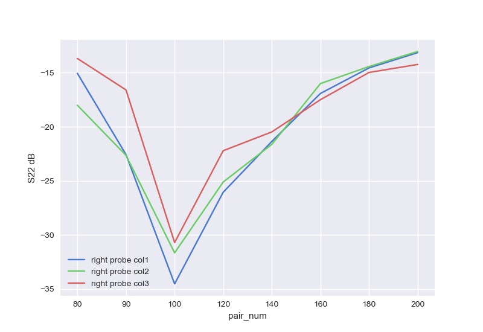

```python
file_name_list = []
for i in range(6, 14):
    file_name = 'right_probe0/d' + str(i) + '.s2p'
    file_name_list.append(file_name)
print(file_name_list)

db_list_right_col1 = []
for file_name in file_name_list:
    bvd_model = BVD_Model()
    bvd_model.load_file(file_name, normalize=True, s_matrix='22')
    db = np.log(np.min(np.absolute(bvd_model.s11_pol))) * 10
    db_list_right_col1.append(db)

file_name_list = []
for i in range(6, 14):
    file_name = 'right_probe1/d' + str(i) + '.s2p'
    file_name_list.append(file_name)
print(file_name_list)

db_list_right_col2 = []
for file_name in file_name_list:
    bvd_model = BVD_Model()
    bvd_model.load_file(file_name, normalize=True, s_matrix='22')
    db = np.log(np.min(np.absolute(bvd_model.s11_pol))) * 10
    db_list_right_col2.append(db)

file_name_list = []
for i in range(6, 14):
    file_name = 'column3/d' + str(i) + '.s2p'
    file_name_list.append(file_name)
print(file_name_list)

db_list_right_col3 = []
for file_name in file_name_list:
    bvd_model = BVD_Model()
    bvd_model.load_file(file_name, normalize=True, s_matrix='22')
    db = np.log(np.min(np.absolute(bvd_model.s11_pol))) * 10
    db_list_right_col3.append(db)

plt.figure()
plt.plot(db_list_right_col1)
plt.plot(db_list_right_col2)
plt.plot(db_list_right_col3)
plt.legend(['right probe col1', 'right probe col2', 'right probe col3'])
plt.xticks(np.arange(0, 8), ['80', '90', '100', '120', '140', '160', '180', '200'])
plt.xlabel('pair_num')
plt.ylabel('S22 dB')
```

## **Conclusion:** For the right port, optimal pair_num is 100

### S11 (left probe) for three columns:

```
['left_probe0/d6.s2p', 'left_probe0/d7.s2p', 'left_probe0/d8.s2p', 'left_probe0/d9.s2p', 'left_probe0/d10.s2p', 'left_probe0/d11.s2p', 'left_probe0/d12.s2p', 'left_probe0/d13.s2p']
['left_probe1/d6.s2p', 'left_probe1/d7.s2p', 'left_probe1/d8.s2p', 'left_probe1/d9.s2p', 'left_probe1/d10.s2p', 'left_probe1/d11.s2p', 'left_probe1/d12.s2p', 'left_probe1/d13.s2p']
['column3/d6.s2p', 'column3/d7.s2p', 'column3/d8.s2p', 'column3/d9.s2p', 'column3/d10.s2p', 'column3/d11.s2p', 'column3/d12.s2p', 'column3/d13.s2p']
```

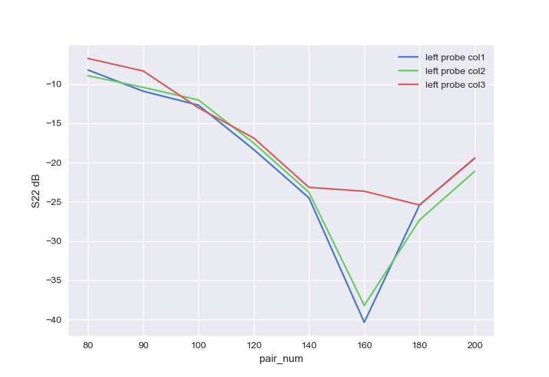

```python
file_name_list = []
for i in range(6, 14):
    file_name = 'left_probe0/d' + str(i) + '.s2p'
    file_name_list.append(file_name)
print(file_name_list)

db_list_left_col1 = []
for file_name in file_name_list:
    bvd_model = BVD_Model()
    bvd_model.load_file(file_name, normalize=True, s_matrix='11')
    db = np.log(np.min(np.absolute(bvd_model.s11_pol))) * 10
    db_list_left_col1.append(db)

file_name_list = []
for i in range(6, 14):
    file_name = 'left_probe1/d' + str(i) + '.s2p'
    file_name_list.append(file_name)
print(file_name_list)

db_list_left_col2 = []
for file_name in file_name_list:
    bvd_model = BVD_Model()
    bvd_model.load_file(file_name, normalize=True, s_matrix='11')
    db = np.log(np.min(np.absolute(bvd_model.s11_pol))) * 10
    db_list_left_col2.append(db)

file_name_list = []
for i in range(6, 14):
    file_name = 'column3/d' + str(i) + '.s2p'
    file_name_list.append(file_name)
print(file_name_list)

db_list_left_col3 = []
for file_name in file_name_list:
    bvd_model = BVD_Model()
    bvd_model.load_file(file_name, normalize=True, s_matrix='11')
    db = np.log(np.min(np.absolute(bvd_model.s11_pol))) * 10
    db_list_left_col3.append(db)

plt.figure()
plt.plot(db_list_left_col1)
plt.plot(db_list_left_col2)
plt.plot(db_list_left_col3)
plt.legend(['left probe col1', 'left probe col2', 'left probe col3'])
plt.xticks(np.arange(0, 8), ['80', '90', '100', '120', '140', '160', '180', '200'])
plt.xlabel('pair_num')
plt.ylabel('S22 dB')
```

## Comparative study 1: in colume 2, measure the same idt device using right and left probe separately

```
['left_probe1/d6.s2p', 'left_probe1/d7.s2p', 'left_probe1/d8.s2p', 'left_probe1/d9.s2p', 'left_probe1/d10.s2p', 'left_probe1/d11.s2p', 'left_probe1/d12.s2p', 'left_probe1/d13.s2p']
['right_probe2_GSG/d6.s2p', 'right_probe2_GSG/d7.s2p', 'right_probe2_GSG/d8.s2p', 'right_probe2_GSG/d9.s2p', 'right_probe2_GSG/d10.s2p', 'right_probe2_GSG/d11.s2p', 'right_probe2_GSG/d12.s2p', 'right_probe2_GSG/d13.s2p']
```

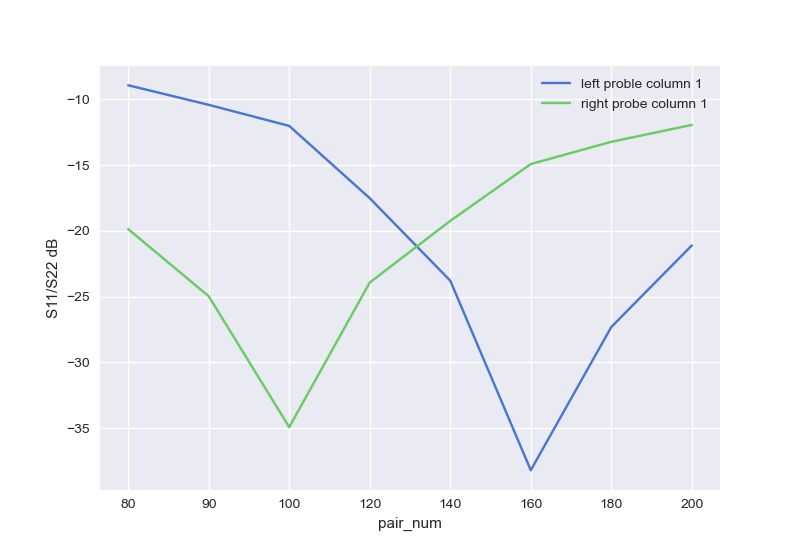

```python
file_name_list = []
for i in range(6, 14):
    file_name = 'left_probe1/d' + str(i) + '.s2p'
    file_name_list.append(file_name)
print(file_name_list)

db_list_left_col2 = []
for file_name in file_name_list:
    bvd_model = BVD_Model()
    bvd_model.load_file(file_name, normalize=True, s_matrix='11')
    db = np.log(np.min(np.absolute(bvd_model.s11_pol))) * 10
    db_list_left_col2.append(db)

file_name_list = []
for i in range(6, 14):
    file_name = 'right_probe2_GSG/d' + str(i) + '.s2p'
    file_name_list.append(file_name)
print(file_name_list)

db_list_right_col2 = []
for file_name in file_name_list:
    bvd_model = BVD_Model()
    bvd_model.load_file(file_name, normalize=True, s_matrix='22')
    db = np.log(np.min(np.absolute(bvd_model.s11_pol))) * 10
    db_list_right_col2.append(db)

plt.figure()
plt.plot(db_list_left_col2)
plt.plot(db_list_right_col2)
plt.legend(['left proble column 1', 'right probe column 1'])
plt.xticks(np.arange(0, 8), ['80', '90', '100', '120', '140', '160', '180', '200'])
plt.xlabel('pair_num')
plt.ylabel('S11/S22 dB')
```

## **Conclusion:** Even for the same idt, left and right probe has different optimal pair_num, with left being 160, right being 100

## Comparative study 2: in colume 2 & 3, measure the same idt device using right probe, but using GSG and GS configurations

```
['column3/d6.s2p', 'column3/d7.s2p', 'column3/d8.s2p', 'column3/d9.s2p', 'column3/d10.s2p', 'column3/d11.s2p', 'column3/d12.s2p', 'column3/d13.s2p']
['col3_right_probe_GS/d6.s2p', 'col3_right_probe_GS/d7.s2p', 'col3_right_probe_GS/d8.s2p', 'col3_right_probe_GS/d9.s2p', 'col3_right_probe_GS/d10.s2p', 'col3_right_probe_GS/d11.s2p', 'col3_right_probe_GS/d12.s2p', 'col3_right_probe_GS/d13.s2p']
```

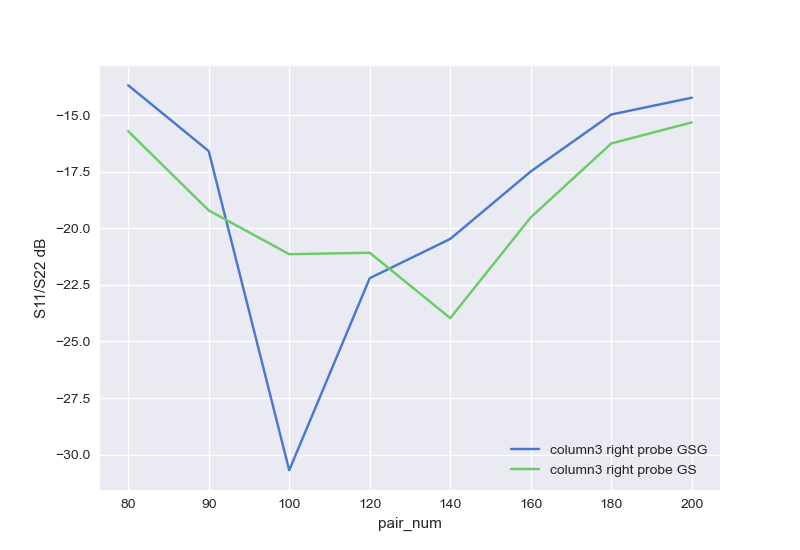

```python
file_name_list = []
for i in range(6, 14):
    file_name = 'column3/d' + str(i) + '.s2p'
    file_name_list.append(file_name)
print(file_name_list)

db_list_right_col3_GSG = []
for file_name in file_name_list:
    bvd_model = BVD_Model()
    bvd_model.load_file(file_name, normalize=True, s_matrix='22')
    db = np.log(np.min(np.absolute(bvd_model.s11_pol))) * 10
    db_list_right_col3_GSG.append(db)

file_name_list = []
for i in range(6, 14):
    file_name = 'col3_right_probe_GS/d' + str(i) + '.s2p'
    file_name_list.append(file_name)
print(file_name_list)

db_list_right_col3_GS = []
for file_name in file_name_list:
    bvd_model = BVD_Model()
    bvd_model.load_file(file_name, normalize=True, s_matrix='22')
    db = np.log(np.min(np.absolute(bvd_model.s11_pol))) * 10
    db_list_right_col3_GS.append(db)

plt.figure()
plt.plot(db_list_right_col3_GSG)
plt.plot(db_list_right_col3_GS)
plt.legend(['column3 right probe GSG', 'column3 right probe GS'])
plt.xticks(np.arange(0, 8), ['80', '90', '100', '120', '140', '160', '180', '200'])
plt.xlabel('pair_num')
plt.ylabel('S11/S22 dB')
```

```
['right_probe2_GS/d6.s2p', 'right_probe2_GS/d7.s2p', 'right_probe2_GS/d8.s2p', 'right_probe2_GS/d9.s2p', 'right_probe2_GS/d10.s2p', 'right_probe2_GS/d11.s2p', 'right_probe2_GS/d12.s2p', 'right_probe2_GS/d13.s2p']
['right_probe2_GSG/d6.s2p', 'right_probe2_GSG/d7.s2p', 'right_probe2_GSG/d8.s2p', 'right_probe2_GSG/d9.s2p', 'right_probe2_GSG/d10.s2p', 'right_probe2_GSG/d11.s2p', 'right_probe2_GSG/d12.s2p', 'right_probe2_GSG/d13.s2p']
```

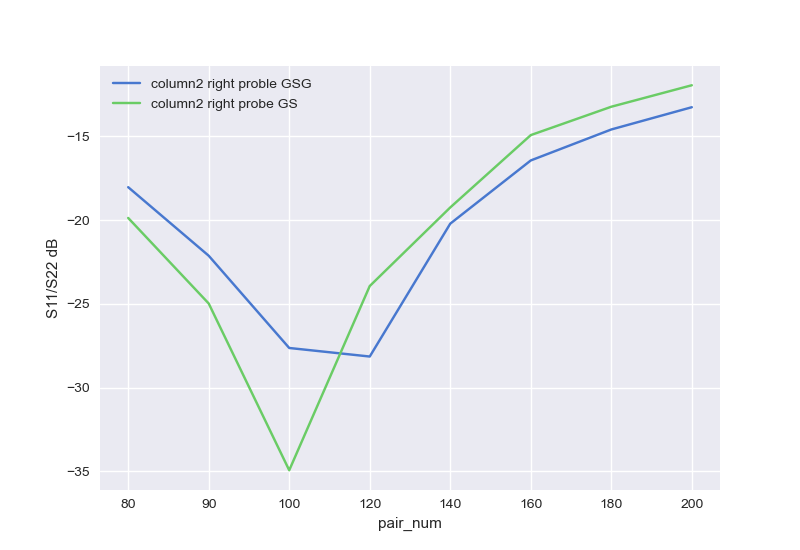

```python
file_name_list = []
for i in range(6, 14):
    file_name = 'right_probe2_GS/d' + str(i) + '.s2p'
    file_name_list.append(file_name)
print(file_name_list)

db_list_right_col2_GSG = []
for file_name in file_name_list:
    bvd_model = BVD_Model()
    bvd_model.load_file(file_name, normalize=True, s_matrix='22')
    db = np.log(np.min(np.absolute(bvd_model.s11_pol))) * 10
    db_list_right_col2_GSG.append(db)

file_name_list = []
for i in range(6, 14):
    file_name = 'right_probe2_GSG/d' + str(i) + '.s2p'
    file_name_list.append(file_name)
print(file_name_list)

db_list_right_col2_GS = []
for file_name in file_name_list:
    bvd_model = BVD_Model()
    bvd_model.load_file(file_name, normalize=True, s_matrix='22')
    db = np.log(np.min(np.absolute(bvd_model.s11_pol))) * 10
    db_list_right_col2_GS.append(db)

plt.figure()
plt.plot(db_list_right_col2_GSG)
plt.plot(db_list_right_col2_GS)
plt.legend(['column2 right proble GSG', 'column2 right probe GS'])
plt.xticks(np.arange(0, 8), ['80', '90', '100', '120', '140', '160', '180', '200'])
plt.xlabel('pair_num')
plt.ylabel('S11/S22 dB')
```

## **Conclusion:** GSG or GS configuration does seem to have some effect on impedance matching, but not that large. It is certainly not the reason left probe optimal pair_num is 160, while right probe optimal num is 100.

## Data collected indicate that left probe and right probe has different optimal impedance match condition. We can:

## 1. choose pair_num to be ~135 such that both left and right probe can achieve -20dB

## 2. make left idt pair_num=160, right idt pair_num=100, so that they each achieve their own optimal impedance matching